# Breast Cancer Survival Analysis

Modified

October 3, 2025

## Exploratory Data Analysis

#### Preamble

Load packages and data:

```r
library(tidyverse)
library(plotly)
library(rafalib)
library(kableExtra)
library(gridExtra)
library(knitr)

library(survival)
library(survminer)


data <- read.csv("../data/data_clean.csv")

# overall_survival is not mutated, as it needs to be numeric for survival analysis
data <- data |>
  mutate(
    tumor_stage = as.factor(tumor_stage),
    her2_status = as.factor(her2_status),
    er_status = as.factor(er_status),
    pr_status = as.factor(pr_status),
    her2_status_measured_by_snp6 = as.factor(her2_status_measured_by_snp6),
    death_from_cancer = as.factor(death_from_cancer),
    neoplasm_histologic_grade = as.factor(neoplasm_histologic_grade),
  )
```

### 1. Survival function

#### 1.1. Assumptions

- Events are independent of each other.
- Right-censoring is uninformative.
- Event times are exact.

#### 1.2. Plotting survival curves

We fit a Kaplan-Meier Survival curve:

```r
km <- survfit(Surv(data$overall_survival_months, data$overall_survival) ~ 1)
km
```

```
Call: survfit(formula = Surv(data$overall_survival_months, data$overall_survival) ~
    1)

        n events median 0.95LCL 0.95UCL
[1,] 1400    610    200     194     211
```

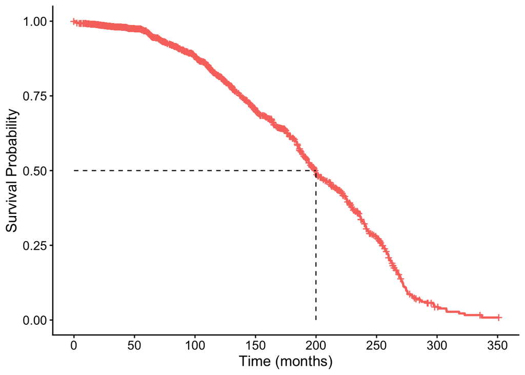

```r
survival_table <- summary(km)

ggsurvplot(km,
           data = data,
           conf.int = FALSE,
           xlab = "Time (months)",
           ylab = "Survival Probability",
           surv.median.line = "hv",
           xlim = c(0, 350),        # show only first 60 months
           break.time.by = 50,      # tick marks every 12 months
           legend = "none")
```

- There were 1,400 patients in total.
- 610 experienced the event (death). The rest (790) were censored.
- The median survival time is 200 months. After that, the survival probability drops below 0.5.
- The 95% confidence interval for the median survival time is 194 to 211 months.

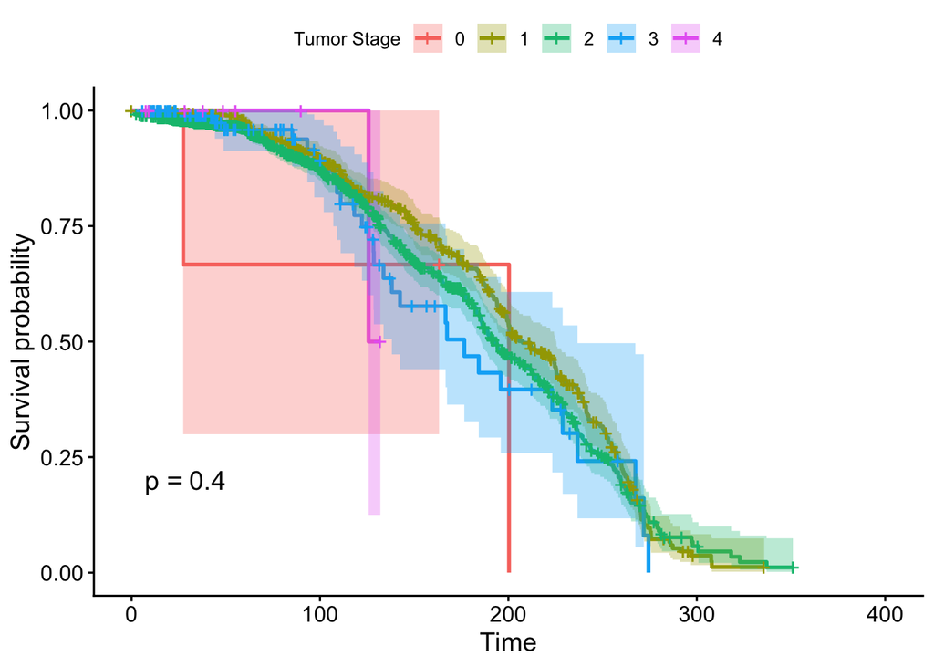

```r
fit_stage <- survfit(Surv(data$overall_survival_months, data$overall_survival) ~ tumor_stage, data = data)

# KM plot with log-rank p-value
ggsurvplot(fit_stage, data = data, pval = TRUE,
           conf.int = TRUE,
           legend.title = "Tumor Stage",
           legend.labs = levels(data$tumor_stage))
```

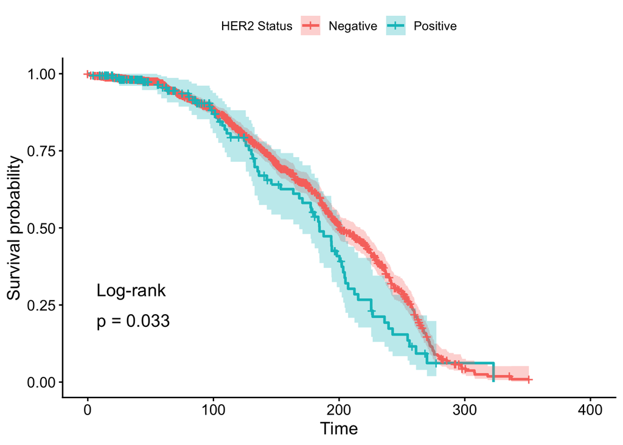

```r
fit_her2 <- survfit(Surv(data$overall_survival_months, data$overall_survival) ~ her2_status, data = data)

# KM plot with log-rank p-value
ggsurvplot(fit_her2, data = data, pval.method = TRUE, pval = TRUE,
           conf.int = TRUE,
           legend.title = "HER2 Status",
           legend.labs = levels(data$her2_status))
```

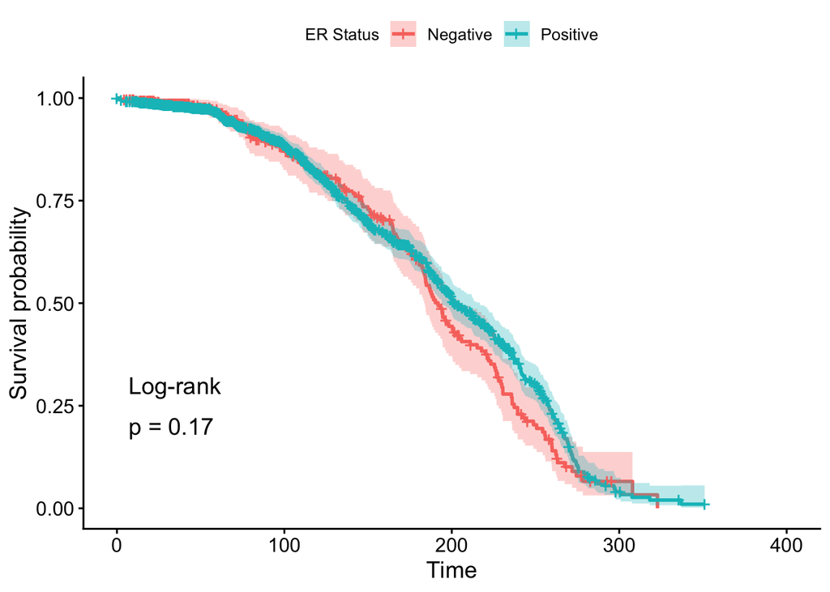

```r
fit_er <- survfit(Surv(data$overall_survival_months, data$overall_survival) ~ er_status, data = data)

# KM plot with log-rank p-value
ggsurvplot(fit_er, data = data, pval.method = TRUE, pval = TRUE,
           conf.int = TRUE,
           legend.title = "ER Status",
           legend.labs = levels(data$er_status))
```

### 2. Cox Proportional Hazards (PH) Model: Assumptions

Same as for the KM curves, but we also need to check for the following:

#### 2. 1. Constant Hazard Ratios (HR) are constant

Hazard ratios between two groups are constant over time. If true, then graphs should be parallel:

(PH log minus log plots imply constant HR assumptions were violated but I fitted the Cox PH model anyway and the residuals were horizontal, so most likely it was because we didn’t adjust for the covariates before– because the crossing of the log minus log plots can be due to a covariate missing as well as time-dependency.)

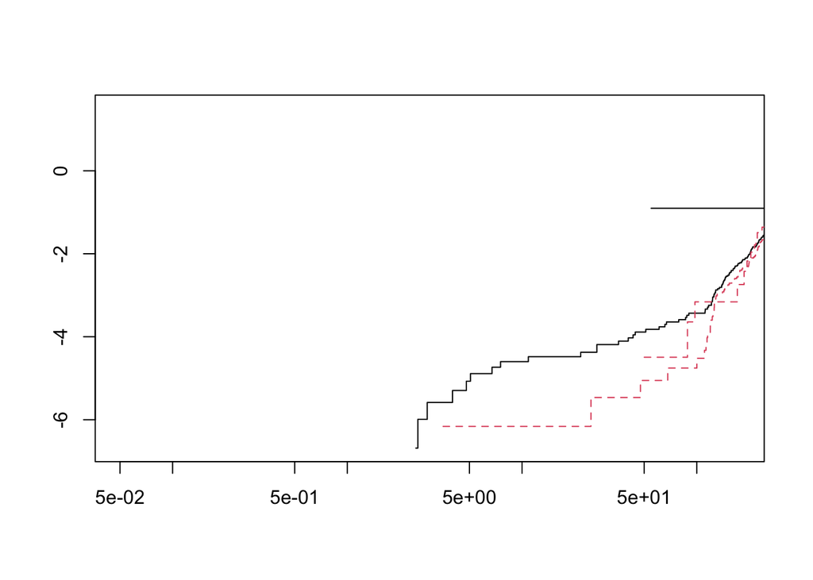

```r
# tumor stage

fit_stage_log <- survfit(Surv(overall_survival_months, overall_survival) ~ tumor_stage, data = data)


plot(fit_stage_log,
     fun = "cloglog",  # log(-log(S))
     xscale = 2,       # log10 scale on x-axis
     col = 1:2,
     lty = 1:2)
```

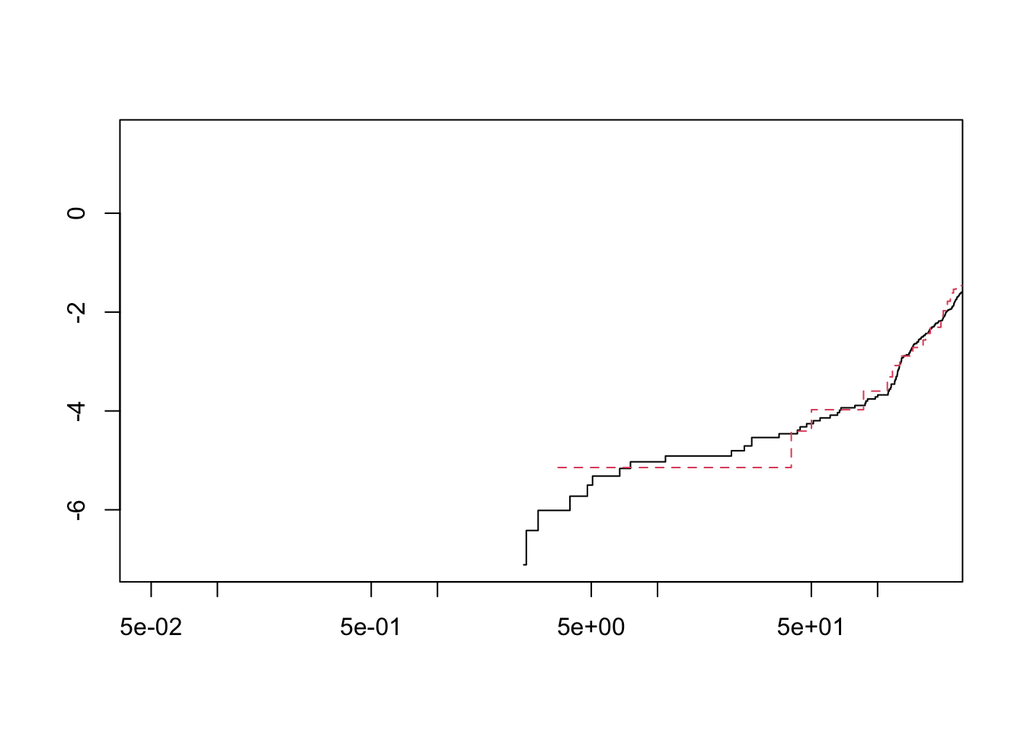

```r
# tumor stage

fit_her2_log <- survfit(Surv(overall_survival_months, overall_survival) ~ her2_status, data = data)


plot(fit_her2_log,
     fun = "cloglog",  # log(-log(S))
     xscale = 2,       # log10 scale on x-axis
     col = 1:2,
     lty = 1:2)
```

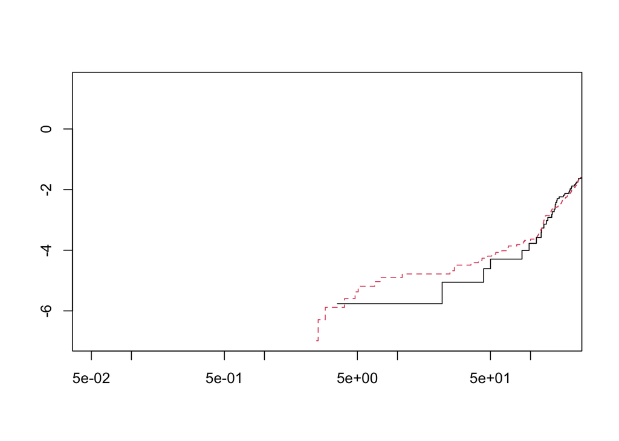

```r
# tumor stage

fit_er_log <- survfit(Surv(overall_survival_months, overall_survival) ~ er_status, data = data)


plot(fit_er_log,
     fun = "cloglog",  # log(-log(S))
     xscale = 2,       # log10 scale on x-axis
     col = 1:2,
     lty = 1:2)
```

```r
fit_her2_log <- survfit(Surv(overall_survival_months, overall_survival) ~ her2_status, data = data)

fit_ph <- coxph(Surv(overall_survival_months, overall_survival) ~ tumor_stage + age_at_diagnosis + her2_status + er_status + lymph_nodes_examined_positive + tumor_size, data = data)

test.ph <- cox.zph(fit_ph)
print(test.ph)
```

```
                                 chisq df     p
tumor_stage                    8.08402  4 0.089
age_at_diagnosis               0.00383  1 0.951
her2_status                    0.04490  1 0.832
er_status                      0.33224  1 0.564
lymph_nodes_examined_positive  0.86253  1 0.353
tumor_size                     0.18162  1 0.670
GLOBAL                        12.89712  9 0.167
```

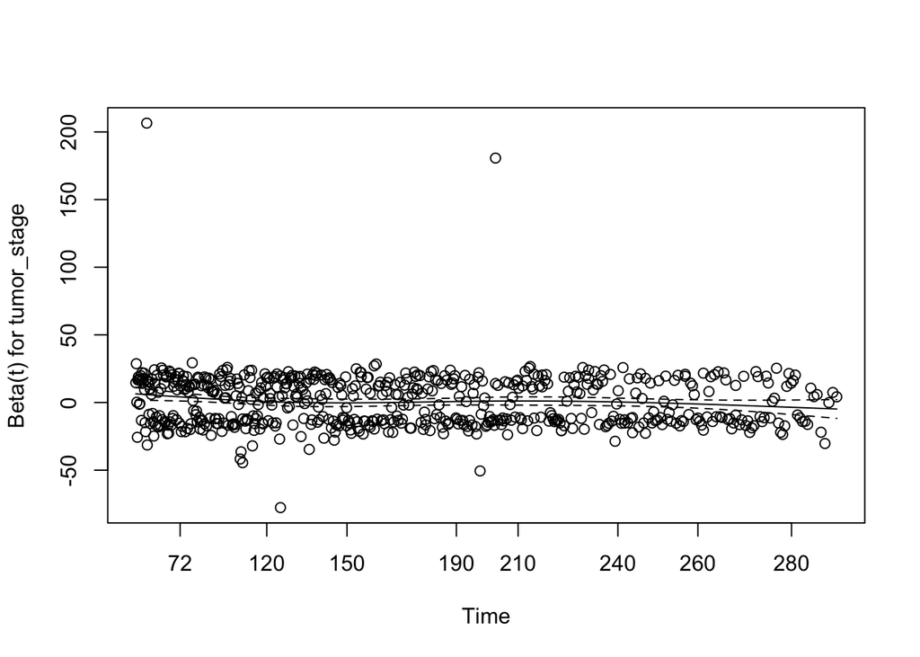

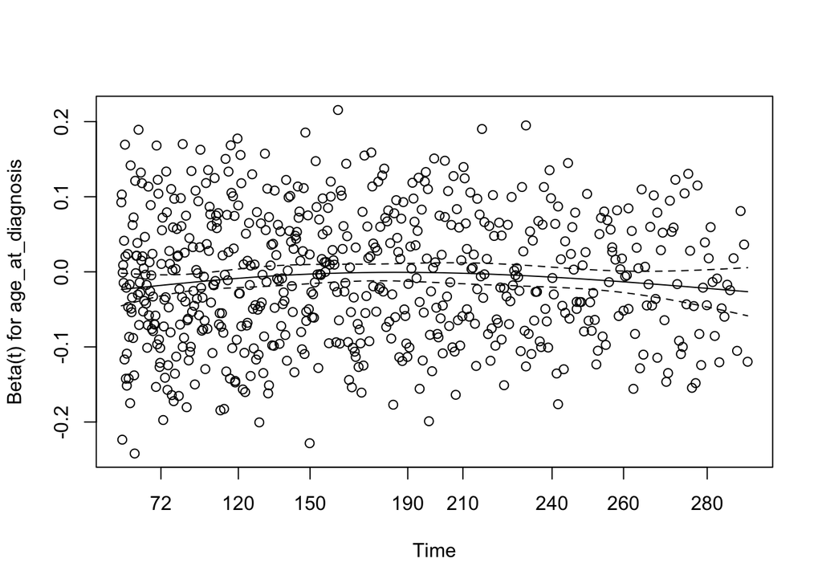

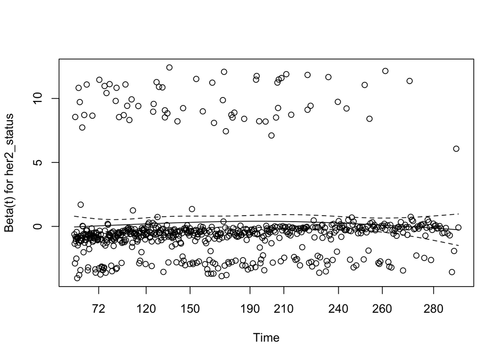

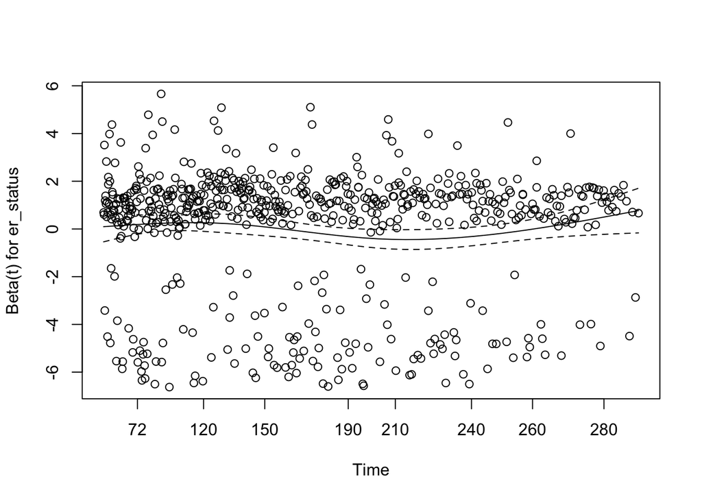

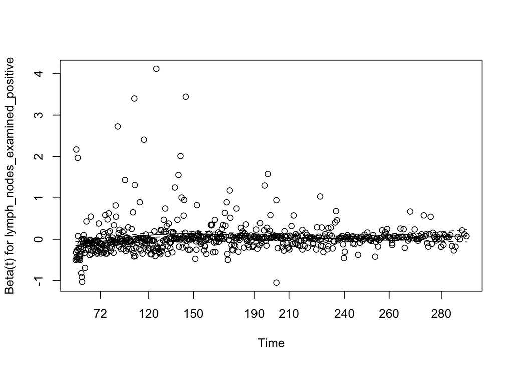

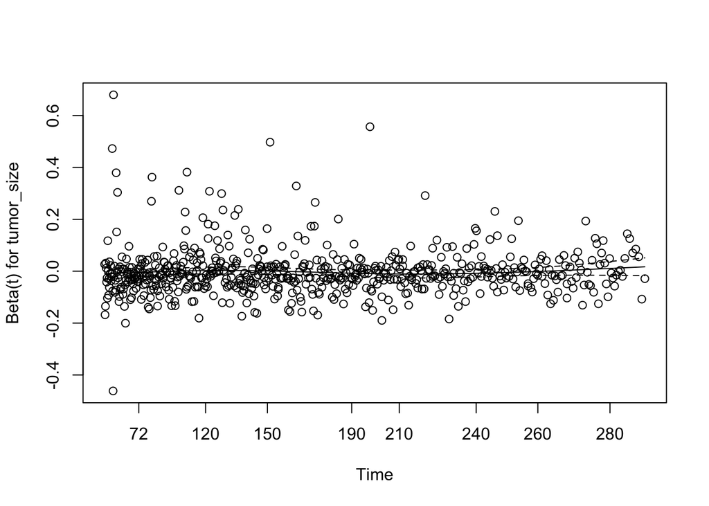

```r
plot(test.ph)
```

#### 2. 2. Linearity

```r
fit_ph <- coxph(Surv(overall_survival_months, overall_survival) ~ tumor_stage + age_at_diagnosis + her2_status + er_status + lymph_nodes_examined_positive + tumor_size, data = data)
```

#### 2. 3. Multicollinearity

```r
cor(data$tumor_size, as.numeric(data$tumor_stage))
```

```
[1] 0.5082442
```